# R Notebook

# Beta diversity

We are interested in the beta diversity between samples after treatment, so we will start by selecting a subset of those and calculating the ordination. We will look at the sequencing depth to get a decent depth for rarefaction.

```r
treat <- subset_samples(total, Day >= 0)
sample_sums(treat)
```

```
 0A-03-04-16  0A-03-06-16  0A-03-08-16  0A-03-10-16  0A-03-12-16  0A-03-14-16  0A-03-16-16  0A-03-18-16
       25938        19426        20341        18582        24528        24440        27464        20848
 0A-03-20-16  0A-03-22-16  0A-03-24-16  0A-03-28-16  0A-04-05-16  0B-03-04-16  0B-03-06-16  0B-03-08-16
       36445        36344        59355        37354        24818        35180        23129        29863
 0B-03-10-16  0B-03-12-16  0B-03-14-16  0B-03-16-16  0B-03-18-16  0B-03-20-16  0B-03-22-16  0B-03-24-16
       33447        31751        32724          141        23541        38642        36905        25001
 0B-03-28-16  0B-04-05-16  0C-03-04-16  0C-03-06-16  0C-03-08-16  0C-03-10-16  0C-03-12-16  0C-03-14-16
       44103        24285        22250        21934        23045        21839        22367        27656
 0C-03-16-16  0C-03-18-16  0C-03-20-16  0C-03-22-16  0C-03-24-16  0C-03-28-16  0C-04-05-16  0D-03-04-16
       20079        36872        36127        41489        29857        38307        37994        21370
 0D-03-06-16  0D-03-08-16  0D-03-10-16  0D-03-12-16  0D-03-14-16  0D-03-16-16  0D-03-18-16  0D-03-20-16
       28436        26548        27167        32111        14607        26249        22400        33167
 0D-03-22-16  0D-03-24-16  0D-03-28-16  0D-04-05-16 16A-03-04-16 16A-03-20-16 16A-03-22-16 16A-03-24-16
       39038        34095        31364        31613        35826        37977        44827        39233
16A-03-28-16 16A-04-05-16 16B-03-04-16 16B-03-20-16 16B-03-22-16 16B-03-24-16 16B-03-28-16 16B-04-05-16
       35562        38498        30173        42483        49342        43064        43241        59719
16C-03-04-16 16C-03-20-16 16C-03-22-16 16C-03-24-16 16C-03-28-16 16C-04-05-16 16D-03-04-16 16D-03-20-16
       36217        58810        77641        72197        46184        65292        27078        75397
16D-03-22-16 16D-03-24-16 16D-03-28-16 16D-04-05-16  2A-03-04-16  2A-03-06-16  2A-03-08-16  2A-03-10-16
       31950        62143        57110        53769        27690        36939        19959        15835
 2A-03-12-16  2A-04-05-16  2B-03-04-16  2B-03-06-16  2B-03-08-16  2B-03-10-16  2B-03-12-16  2B-04-05-16
       43116        41766        21286        40555        38065        32678        28515        38670
 2C-03-04-16  2C-03-06-16  2C-03-08-16  2C-03-10-16  2C-03-12-16  2C-04-05-16  2D-03-04-16  2D-03-06-16
       20894        43412        43212        73031        74310        58038        23299        35564
 2D-03-08-16  2D-03-10-16  2D-03-12-16  2D-04-05-16  4A-03-04-16  4A-03-08-16  4A-03-10-16  4A-03-12-16
       38772        26244        26583        22348        27996        40519        50706        31586
 4A-03-14-16  4A-04-05-16  4B-03-04-16  4B-03-08-16  4B-03-10-16  4B-03-12-16  4B-03-14-16  4B-04-05-16
       25645        31110        25791        46740        40803        25878        32761        67481
 4C-03-04-16  4C-03-08-16  4C-03-10-16  4C-03-12-16  4C-03-14-16  4C-04-05-16  4D-03-04-16  4D-03-08-16
       21823        61699        43369        35183        24828        38650        32858        60718
 4D-03-10-16  4D-03-12-16  4D-03-14-16  4D-04-05-16  8A-03-04-16  8A-03-12-16  8A-03-14-16  8A-03-16-16
       57733        36187        28068        51463        26473        40796        36220        38154
 8A-04-05-16  8B-03-04-16  8B-03-12-16  8B-03-14-16  8B-03-16-16  8B-04-05-16  8C-03-04-16  8C-03-12-16
       67252        25622       139911        48125        34804        60321        23087        58161
 8C-03-14-16  8C-03-16-16  8C-04-05-16  8D-03-04-16  8D-03-12-16  8D-03-14-16  8D-03-16-16  8D-04-05-16
       53909        84614        44093        36589        42877        36206        31133        55455
```

Okay so we can easily rarefy to 10K reads.

```r
ord <- rarefy_even_depth(treat, 10000) %>%
       ordinate(., method = "PCoA", distance = "bray")
```

```
You set `rngseed` to FALSE. Make sure you've set & recorded
 the random seed of your session for reproducibility.
See `?set.seed`

...
1 samples removedbecause they contained fewer reads than `sample.size`.
Up to first five removed samples are:

0B-03-16-16
...
998OTUs were removed because they are no longer
present in any sample after random subsampling

...
```

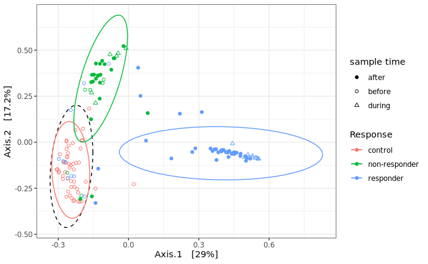

```r
sda <- sample_data(treat)
sample_data(treat)$since_treatment <- factor(sda$Day - sda$duration)

data <- plot_ordination(treat, ord, color = "Response",
                      shape = "TimepointCat", justDF = T)
pl <- plot_ordination(treat, ord, color = "Response",
                      shape = "TimepointCat") +
      stat_ellipse(data=data[data$TimepointCat == "before", ],
                   aes(group = TimepointCat), lty="dashed") +
      stat_ellipse(aes(group = Response), type = "t") +
      scale_shape_manual(values = c(before = 1, during = 2, after = 19)) +
      labs(shape = "sample time") + theme_bw()

fig_data[["Fig. 1D"]] <- data
ggsave("figures/treatment_pcoa_duration.svg", width = 6, height = 4)
pl
```

# Corresponding PERMANOVA

Before exposure:

```r
library(vegan)

ps <- subset_samples(treat, TimepointCat == "before") %>%
      rarefy_even_depth(., 10000)
```

```
You set `rngseed` to FALSE. Make sure you've set & recorded
 the random seed of your session for reproducibility.
See `?set.seed`

...
1 samples removedbecause they contained fewer reads than `sample.size`.
Up to first five removed samples are:

0B-03-16-16
...
1576OTUs were removed because they are no longer
present in any sample after random subsampling

...
```

```r
counts <- as.matrix(taxa_count(ps, NA))
sda <- as(sample_data(ps), "data.frame")
permanova <- adonis(counts ~ Response, data = sda)
permanova
```

```
Call:
adonis(formula = counts ~ Response, data = sda)

Permutation: free
Number of permutations: 999

Terms added sequentially (first to last)

          Df SumsOfSqs MeanSqs F.Model      R2 Pr(>F)
Response   2    0.6595 0.32976  3.4241 0.09666  0.002 **
Residuals 64    6.1636 0.09631         0.90334
Total     66    6.8232                 1.00000
---
Signif. codes:  0 ‘***’ 0.001 ‘**’ 0.01 ‘*’ 0.05 ‘.’ 0.1 ‘ ’ 1
```

After exposure:

```r
library(vegan)

ps <- subset_samples(treat, TimepointCat != "before") %>%
      rarefy_even_depth(., 10000)
```

```
You set `rngseed` to FALSE. Make sure you've set & recorded
 the random seed of your session for reproducibility.
See `?set.seed`

...
1228OTUs were removed because they are no longer
present in any sample after random subsampling

...
```

```r
counts <- as.matrix(taxa_count(ps, NA))
sda <- as(sample_data(ps), "data.frame")
permanova <- adonis(counts ~ Response, data = sda)
permanova
```

```
Call:
adonis(formula = counts ~ Response, data = sda)

Permutation: free
Number of permutations: 999

Terms added sequentially (first to last)

          Df SumsOfSqs MeanSqs F.Model      R2 Pr(>F)
Response   1    6.7155  6.7155  23.161 0.23838  0.001 ***
Residuals 74   21.4562  0.2899         0.76162
Total     75   28.1717                 1.00000
---
Signif. codes:  0 ‘***’ 0.001 ‘**’ 0.01 ‘*’ 0.05 ‘.’ 0.1 ‘ ’ 1
```

# Gained/lost taxa

We will now track which taxa where gained or lost in each mouse over the treatment course.

```r
asvs <- taxa_count(total, NA)
asvs <- asvs[sdata, on = c(sample = "Description")][Day %in% c(0, 32)]
asvs
```

| sample | taxa | reads | species | SampleID | Mouse | GroupSpore | GroupCat | Group | DateCat | EpochDateCat | EpochDate | SporeCat | Spore | DayCat | Day | GroupDay | GroupSporeDay | Response | ResponseDay | GroupSporeResponseDay | duration | TimepointCat |
| --- | --- | --- | --- | --- | --- | --- | --- | --- | --- | --- | --- | --- | --- | --- | --- | --- | --- | --- | --- | --- | --- | --- |
| 0A-03-04-16 | 6248d8dc58586698bc31c466d19e1d25 | 0 | Turicibacter NA | 0A.d00.total | 0A | 00.total | 0 | 0 | 3/4/16 | 16864 | 16864 | total | 0 | 0 | 0 | 00.d00 | 00.total.d00 | control | cnt.d00 | 00.total.cnt.d00 | 0 | before |
| 0A-03-04-16 | b7cf5d28876a5c3bf217d9bdd36966f6 | 12090 | NA | 0A.d00.total | 0A | 00.total | 0 | 0 | 3/4/16 | 16864 | 16864 | total | 0 | 0 | 0 | 00.d00 | 00.total.d00 | control | cnt.d00 | 00.total.cnt.d00 | 0 | before |
| 0A-03-04-16 | d4c914a6ab2cac32253d7a5c88439e9f | 1131 | NA | 0A.d00.total | 0A | 00.total | 0 | 0 | 3/4/16 | 16864 | 16864 | total | 0 | 0 | 0 | 00.d00 | 00.total.d00 | control | cnt.d00 | 00.total.cnt.d00 | 0 | before |
| 0A-03-04-16 | 4ea517a5ae33d37d6fa7e4a183f4f9c4 | 0 | Lachnoclostridium_5 NA | 0A.d00.total | 0A | 00.total | 0 | 0 | 3/4/16 | 16864 | 16864 | total | 0 | 0 | 0 | 00.d00 | 00.total.d00 | control | cnt.d00 | 00.total.cnt.d00 | 0 | before |
| 0A-03-04-16 | ae1cc7a25d7e7944d5fbd20b2ce202e4 | 666 | NA | 0A.d00.total | 0A | 00.total | 0 | 0 | 3/4/16 | 16864 | 16864 | total | 0 | 0 | 0 | 00.d00 | 00.total.d00 | control | cnt.d00 | 00.total.cnt.d00 | 0 | before |
| 0A-03-04-16 | 060805253b47e575ca0b58d5ed0609b0 | 645 | Lachnospiraceae_NK4A136_group bacterium | 0A.d00.total | 0A | 00.total | 0 | 0 | 3/4/16 | 16864 | 16864 | total | 0 | 0 | 0 | 00.d00 | 00.total.d00 | control | cnt.d00 | 00.total.cnt.d00 | 0 | before |
| 0A-03-04-16 | 9f5f3fddc7cbd876639d42bfcaf57c94 | 55 | NA | 0A.d00.total | 0A | 00.total | 0 | 0 | 3/4/16 | 16864 | 16864 | total | 0 | 0 | 0 | 00.d00 | 00.total.d00 | control | cnt.d00 | 00.total.cnt.d00 | 0 | before |
| 0A-03-04-16 | 5de01a937f7b6465a7f545e7523c56d0 | 75 | Clostridium_sensu_stricto_1 NA | 0A.d00.total | 0A | 00.total | 0 | 0 | 3/4/16 | 16864 | 16864 | total | 0 | 0 | 0 | 00.d00 | 00.total.d00 | control | cnt.d00 | 00.total.cnt.d00 | 0 | before |
| 0A-03-04-16 | 72e17d1102688080393ff26f45102f41 | 1589 | NA | 0A.d00.total | 0A | 00.total | 0 | 0 | 3/4/16 | 16864 | 16864 | total | 0 | 0 | 0 | 00.d00 | 00.total.d00 | control | cnt.d00 | 00.total.cnt.d00 | 0 | before |
| 0A-03-04-16 | bb097a415989487241ced90c37148e1b | 0 | Enterococcus NA | 0A.d00.total | 0A | 00.total | 0 | 0 | 3/4/16 | 16864 | 16864 | total | 0 | 0 | 0 | 00.d00 | 00.total.d00 | control | cnt.d00 | 00.total.cnt.d00 | 0 | before |

[output cut: 990 more lines]

Now lets us assign which ASVs have persisted, were gained or lost.

```r
status <- function(dt) {
  if (nrow(dt) == 2) return("persisted")
  if (nrow(dt) == 1 && dt$Day == 0) return("lost")
  return("gained")
}

history <- asvs[reads > 0, .(status = status(.SD), taxon = taxa[1],
                             mouse = Mouse[1], duration = duration[1],
                             response = Response[1]),
                by = c("Mouse", "taxa")]
status_counts <- history[, .(n = .N, duration = duration[1],
                             response = response[1]),
                         by = c("mouse", "status")]
status_counts[, duration := factor(duration)]
fig_data[["Fig. 1E"]] <- status_counts
```

Now let’s plot all of that:

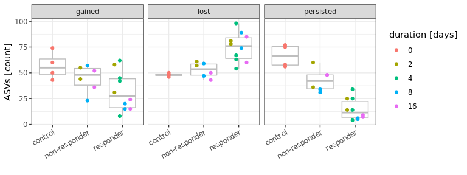

```r
pl <- ggplot(status_counts,
             aes(x = response, y = n, group = duration, color = duration)) +
  geom_boxplot(col = "gray", aes(group = response), outlier.shape = NA) +
  geom_point(position = position_dodge(width = 0.6)) +
  facet_wrap(~ status) + theme_bw() +
  theme(axis.text.x = element_text(angle = 30, hjust = 1, vjust = 1)) +
  labs(x = "", y = "ASVs [count]", color = "duration [days]")
ggsave("figures/avs_history.svg", height = 3, width = 8)
pl
```

And the corresponding tests:

```r
for (lev in status_counts[, unique(status)]) {
  cat(lev)
  pairwise.wilcox.test(status_counts[status == lev, n],
                       status_counts[status == lev, response],
                       p.adjust.method = "bonferroni") %>% print
}
```

```
persisted
```

```
cannot compute exact p-value with tiescannot compute exact p-value with tiescannot compute exact p-value with ties
```

```
    Pairwise comparisons using Wilcoxon rank sum test with continuity correction

data:  status_counts[status == lev, n] and status_counts[status == lev, response]

              control non-responder
non-responder 0.127   -
responder     0.017   0.007

P value adjustment method: bonferroni
lost
```

```
cannot compute exact p-value with tiescannot compute exact p-value with ties
```

```
    Pairwise comparisons using Wilcoxon rank sum test with continuity correction

data:  status_counts[status == lev, n] and status_counts[status == lev, response]

              control non-responder
non-responder 1.000   -
responder     0.017   0.009

P value adjustment method: bonferroni
gained
```

```
cannot compute exact p-value with tiescannot compute exact p-value with ties
```

```
    Pairwise comparisons using Wilcoxon rank sum exact test

data:  status_counts[status == lev, n] and status_counts[status == lev, response]

              control non-responder
non-responder 1.00    -
responder     0.17    0.76

P value adjustment method: bonferroni
```

# Time courses

## Shannon index

```r
shannon <- estimate_richness(rarefy_even_depth(total, 10000),
                             measures = "Shannon")
```

```
You set `rngseed` to FALSE. Make sure you've set & recorded
 the random seed of your session for reproducibility.
See `?set.seed`

...
1 samples removedbecause they contained fewer reads than `sample.size`.
Up to first five removed samples are:

0B-03-16-16
...
984OTUs were removed because they are no longer
present in any sample after random subsampling

...
```

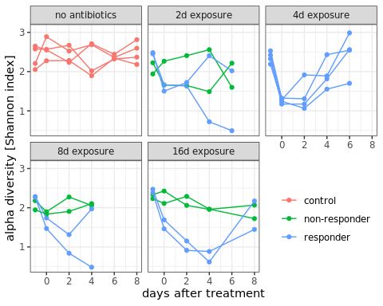

```r
shannon <- data.table(sample = rownames(shannon), shannon = shannon[, 1])
shannon <- shannon[sdata, on = c(sample = "Description")]
shannon[Day >= 0 & Day < 32, Day := Day - duration]
shannon[, "exposure" := sprintf("%dd exposure", duration)]
shannon[duration == 0, exposure := "no antibiotics"]

pl <- ggplot(shannon[Day >= -1],
             aes(x = Day, y = shannon, color = Response)) +
  geom_point(aes(group=Mouse)) +
  geom_line(aes(group=Mouse)) +
  #stat_summary(fun.data = mean_sdl, fun.args = list(mult = 1),
  #             geom = "pointrange") +
  #stat_summary(fun.data = mean_sdl, fun.args = list(mult = 1), geom = "line") +
  xlim(-1, 8) + theme_bw() +
  labs(y = "alpha diversity [Shannon index]", x = "days after treatment", color = "") +
  facet_wrap(~ reorder(exposure, duration)) +
  theme(legend.position = c(0.85, 0.25))

fig_data[["Fig. 3A"]] <- shannon
ggsave("figures/shannon_time.svg", width = 6, height = 4)
pl
```

```r
r = shannon[Response == "responder"]
nrow(r[Day %in% c(2, 6, 8)])
```

```
[1] 18
```

```r
wilcox.test(r[Day == 2, shannon], r[Day %in% c(6, 8), shannon])
```

```
    Wilcoxon rank sum exact test

data:  r[Day == 2, shannon] and r[Day %in% c(6, 8), shannon]
W = 15, p-value = 0.02665
alternative hypothesis: true location shift is not equal to 0
```

```r
nrc = shannon[Response != "responder" & Day >= 0]
nrow(nrc)
```

```
[1] 80
```

```r
wilcox.test(nrc[Day == 2, shannon], nrc[Day %in% c(6, 8), shannon])
```

```
    Wilcoxon rank sum exact test

data:  nrc[Day == 2, shannon] and nrc[Day %in% c(6, 8), shannon]
W = 55, p-value = 0.7713
alternative hypothesis: true location shift is not equal to 0
```

## Differential tests

We will use corn cob to test for differences in abundance between responders and non-responders for each timepoint category.

We will use a few helpers to summarize the tables and corncob output.

```r
source("helpers.R")
```

### For phyla

Controls vs non-responders

```r
library(corncob)

phylum <- subset_samples(treat, TimepointCat == "before") %>% collapse("Phylum", 1e-3)

tests <- differentialTest(
  formula = ~ Response,
  phi.formula = ~ 1,
  formula_null = ~ 1,
  phi.formula_null = ~ 1,
  data = phylum,
  test = "LRT",
  boot = F
) %>% results_table()

fwrite(tests, "data/tests_duration_before_phyla.csv")
tests[order(padj)]
```

| taxon | pvalue | padj | coef | se | variable |
| --- | --- | --- | --- | --- | --- |
| Firmicutes | 0.2227248 | 0.8412675 | -0.15148601 | 1.862435e-01 | mu.Responsenon-responder |
| Bacteroidetes | 0.3774053 | 0.8412675 | 0.04139171 | 1.891833e-01 | mu.Responsenon-responder |
| Proteobacteria | 0.8240163 | 0.8412675 | -0.21377959 | 3.644173e-01 | mu.Responsenon-responder |
| Cyanobacteria | 0.8284193 | 0.8412675 | -0.20184448 | 3.986819e-01 | mu.Responsenon-responder |
| Tenericutes | 0.8412675 | 0.8412675 | -0.18622081 | 3.643726e-01 | mu.Responsenon-responder |
| Verrucomicrobia | NA | NA | -22.95851775 | 1.133159e+05 | mu.Responsenon-responder |

Non-responders vs. responders

```r
library(corncob)

phylum <- subset_samples(treat, Response != "control") %>% collapse("Phylum")
cats <- levels(sample_data(phylum)$TimepointCat)
xtabs(~ Response + TimepointCat, as(sample_data(phylum), "data.frame"))
```

```
               TimepointCat
Response        before during after
  non-responder      6      6    22
  responder         10     10    38
```

```r
tests <- lapply(cats, function(cat) {
  tests <- differentialTest(
    formula = ~ Response,
    phi.formula = ~ 1,
    formula_null = ~ 1,
    phi.formula_null = ~ 1,
    data = prune_samples(sample_data(phylum)$TimepointCat == cat, phylum),
    test = "LRT",
    boot = F
  ) %>% results_table()
  tests$TimepointCat <- cat
  tests
}) %>% rbindlist()
```

```r
fwrite(tests[order(padj)], "data/tests_duration_during_phyla.csv")
tests[padj<0.05, table(TimepointCat)]
```

```
TimepointCat
 after during
     5      4
```

```r
tests[padj < 0.05]
```

| taxon | pvalue | padj | coef | se | variable | TimepointCat |
| --- | --- | --- | --- | --- | --- | --- |
| Firmicutes | 4.197181e-10 | 5.246476e-10 | -2.8063722 | 0.2332376 | mu.Responseresponder | during |
| Bacteroidetes | 5.483632e-12 | 9.139387e-12 | -4.1938305 | 0.2745832 | mu.Responseresponder | during |
| Proteobacteria | 3.259190e-14 | 8.147976e-14 | 4.0675145 | 0.2851111 | mu.Responseresponder | during |
| Cyanobacteria | 8.803242e-16 | 4.401621e-15 | 5.2431128 | 0.4050598 | mu.Responseresponder | during |
| Firmicutes | 2.783442e-15 | 6.958606e-15 | 2.4642996 | 0.2417373 | mu.Responseresponder | after |
| Bacteroidetes | 9.798870e-16 | 4.899435e-15 | -3.2302589 | 0.3137540 | mu.Responseresponder | after |
| Proteobacteria | 8.713525e-03 | 8.713525e-03 | 0.5846142 | 0.2267316 | mu.Responseresponder | after |
| Cyanobacteria | 1.357992e-05 | 1.697489e-05 | 1.0837824 | 0.2563400 | mu.Responseresponder | after |
| Tenericutes | 7.908733e-10 | 1.318122e-09 | -2.6255074 | 0.4715781 | mu.Responseresponder | after |

```r
phylum <- subset_samples(treat, Response != "responder") %>% collapse("Phylum", 1e-3, 0.8)

tests <- differentialTest(
  formula = ~ Response,
  phi.formula = ~ 1,
  formula_null = ~ 1,
  phi.formula_null = ~ 1,
  data = phylum,
  test = "LRT",
  boot = F
) %>% results_table()

fwrite(tests, "data/tests_duration_control_vs_non_phyla.csv")
tests[order(padj)]
```

| taxon | pvalue | padj | coef | se | variable |
| --- | --- | --- | --- | --- | --- |
| Tenericutes | 0.001104913 | 0.006629476 | -0.67954276 | 0.2125221 | mu.Responsenon-responder |
| Firmicutes | 0.235076928 | 0.705230783 | -0.11957322 | 0.1006278 | mu.Responsenon-responder |
| Bacteroidetes | 0.430731320 | 0.861462639 | 0.08362929 | 0.1061300 | mu.Responsenon-responder |
| Proteobacteria | 0.934219773 | 0.973848396 | 0.01474126 | 0.1784778 | mu.Responsenon-responder |
| Cyanobacteria | 0.898641802 | 0.973848396 | 0.02633673 | 0.2065694 | mu.Responsenon-responder |
| Verrucomicrobia | 0.973848396 | 0.973848396 | -0.02119945 | 0.6471252 | mu.Responsenon-responder |

For genera:

```r
library(corncob)

genera <- subset_samples(treat, TimepointCat == "before" & Response != "responder") %>% collapse("Genus", 1e-3, 0.8)

tests <- differentialTest(
  formula = ~ Response,
  phi.formula = ~ 1,
  formula_null = ~ 1,
  phi.formula_null = ~ 1,
  data = genera,
  test = "LRT",
  boot = F
) %>% results_table()

fwrite(tests, "data/tests_duration_before_genera.csv")
tests[order(padj)]
```

| taxon | pvalue | padj | coef | se | variable |
| --- | --- | --- | --- | --- | --- |
| Ruminococcus_1 | 4.968724e-05 | 0.001242181 | -2.06660062 | 7.180884e-01 | mu.Responsenon-responder |
| Turicibacter | 2.909333e-04 | 0.003636667 | -1.93290213 | 7.237378e-01 | mu.Responsenon-responder |
| Clostridium_sensu_stricto_1 | 1.139919e-02 | 0.094993268 | -1.46679717 | 7.266327e-01 | mu.Responsenon-responder |
| Lachnospiraceae_UCG-001 | 4.642404e-02 | 0.290150223 | -0.68283388 | 3.818177e-01 | mu.Responsenon-responder |
| A2 | 8.442657e-02 | 0.422132871 | 1.05240848 | 5.391536e-01 | mu.Responsenon-responder |
| Lactobacillus | 1.559566e-01 | 0.508911148 | -0.53747464 | 4.145520e-01 | mu.Responsenon-responder |
| Erysipelatoclostridium | 1.628516e-01 | 0.508911148 | 0.62022830 | 4.061979e-01 | mu.Responsenon-responder |
| Ruminiclostridium_5 | 1.582078e-01 | 0.508911148 | 0.43040845 | 2.773055e-01 | mu.Responsenon-responder |
| Ruminococcaceae_UCG-014 | 2.309317e-01 | 0.641477056 | -0.39749626 | 3.557656e-01 | mu.Responsenon-responder |
| Ruminiclostridium_9 | 2.599389e-01 | 0.649847325 | 0.26288288 | 2.189842e-01 | mu.Responsenon-responder |

[output cut: 18 more lines]

```r
genera <- subset_samples(treat, Response != "control") %>% collapse("Genus")
cats <- levels(sample_data(genera)$TimepointCat)

tests <- lapply(cats, function(cat) {
  tests <- differentialTest(
    formula = ~ Response,
    phi.formula = ~ 1,
    formula_null = ~ 1,
    phi.formula_null = ~ 1,
    data = prune_samples(sample_data(genera)$TimepointCat == cat, genera),
    test = "LRT",
    boot = F
  ) %>% results_table()
  tests$TimepointCat <- cat
  tests
}) %>% rbindlist()
```

```r
fwrite(tests[order(padj)], "data/tests_duration_during_genera.csv")
tests[padj<0.05, table(TimepointCat)]
```

```
TimepointCat
 after during
    21      6
```

```r
tests[order(padj)]
```

| taxon | pvalue | padj | coef | se | variable | TimepointCat |
| --- | --- | --- | --- | --- | --- | --- |
| GCA-900066575 | 4.289953e-23 | 9.437898e-22 | -5.011682614 | 7.410942e-01 | mu.Responseresponder | after |
| Oscillibacter | 2.100659e-20 | 2.310725e-19 | -3.961237737 | 4.421355e-01 | mu.Responseresponder | after |
| Intestinimonas | 1.169099e-17 | 8.557868e-17 | -3.784006340 | 5.034046e-01 | mu.Responseresponder | after |
| Ruminiclostridium_9 | 1.555976e-17 | 8.557868e-17 | -3.331897432 | 3.936709e-01 | mu.Responseresponder | after |
| ASF356 | 3.177332e-16 | 1.398026e-15 | -4.838631018 | 1.029636e+00 | mu.Responseresponder | after |
| Ruminiclostridium | 1.484512e-14 | 5.443212e-14 | -3.521845626 | 5.520170e-01 | mu.Responseresponder | after |
| Lachnospiraceae_NK4A136_group | 4.012440e-13 | 1.261053e-12 | -3.242077694 | 4.016499e-01 | mu.Responseresponder | after |
| Acetatifactor | 1.303843e-12 | 3.585568e-12 | -2.878042179 | 4.227245e-01 | mu.Responseresponder | after |
| Ruminiclostridium_5 | 2.630025e-11 | 6.428949e-11 | -2.483160921 | 3.803779e-01 | mu.Responseresponder | after |
| Anaeroplasma | 6.905868e-11 | 1.519291e-10 | -2.842370892 | 4.765966e-01 | mu.Responseresponder | after |

[output cut: 125 more lines]

```r
genera <- subset_samples(treat, Response != "responder") %>% collapse("Genus", 1e-3, 0.8)

tests <- differentialTest(
  formula = ~ Response,
  phi.formula = ~ 1,
  formula_null = ~ 1,
  phi.formula_null = ~ 1,
  data = genera,
  test = "LRT",
  boot = F
) %>% results_table()

fwrite(tests, "data/tests_duration_control_vs_non_genera.csv")
tests[order(padj)]
```

| taxon | pvalue | padj | coef | se | variable |
| --- | --- | --- | --- | --- | --- |
| Lachnospiraceae_UCG-001 | 3.699627e-19 | 9.988994e-18 | -2.38279922 | 0.2929740 | mu.Responsenon-responder |
| Ruminococcaceae_UCG-014 | 1.169428e-16 | 1.578728e-15 | -2.17306515 | 0.2916517 | mu.Responsenon-responder |
| Lactobacillus | 2.183940e-15 | 1.965546e-14 | -2.07259479 | 0.2852309 | mu.Responsenon-responder |
| Turicibacter | 2.919611e-15 | 1.970738e-14 | -2.55377513 | 0.4074124 | mu.Responsenon-responder |
| Ruminococcus_1 | 4.883626e-14 | 2.637158e-13 | -2.20106178 | 0.3463213 | mu.Responsenon-responder |
| Clostridium_sensu_stricto_1 | 9.071768e-13 | 4.082295e-12 | -2.75612226 | 0.5267508 | mu.Responsenon-responder |
| Roseburia | 6.891672e-11 | 2.658216e-10 | -1.46265389 | 0.2275850 | mu.Responsenon-responder |
| Tyzzerella_3 | 9.572533e-10 | 3.230730e-09 | -1.91135884 | 0.3651069 | mu.Responsenon-responder |
| Ruminiclostridium | 1.345249e-09 | 4.035747e-09 | -1.24036924 | 0.2083795 | mu.Responsenon-responder |
| Lachnospiraceae_UCG-006 | 2.383281e-08 | 6.434858e-08 | -1.77420097 | 0.3668269 | mu.Responsenon-responder |

[output cut: 17 more lines]

## Major phyla timecourses

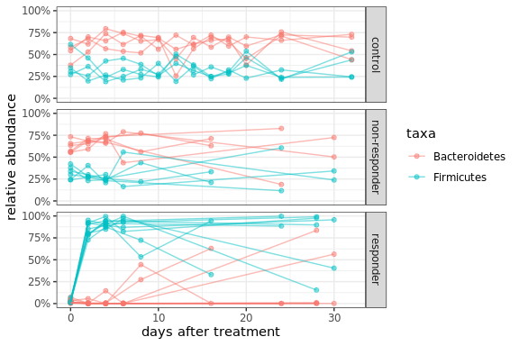

```r
shifted <- phyla[Day - duration >= 0 & Day <= 32]
shifted[, Day := Day - duration]
shifted[, relative := reads / sum(reads), by = "sample"]

pl <- ggplot(shifted[taxa %in% c("Bacteroidetes", "Firmicutes")],
             aes(x = Day, y = relative, col = taxa)) +
  geom_point(alpha = 0.5) + scale_y_continuous(labels = scales::percent) +
  geom_line(aes(group = interaction(Mouse, taxa)), alpha = 0.5) +
  facet_wrap(~ Response, nrow = 3, strip.position = "right") + theme_bw() +
  labs(x = "days after treatment", y = "relative abundance")

fig_data[["Fig. 3B"]] <- shifted[taxa %in% c("Bacteroidetes", "Firmicutes")]
ggsave("figures/bac_firm_time.svg", width = 6, height = 4)
pl
```

Finally we will save the raw data for the figures to be filled in by the other notebooks.

```r
saveRDS(fig_data, "data/fig_data.rds")
```